# CMP330 Data Analytics - Assessment 2 (Pre-Assignment)

Habibur Rahman [B01009639]

# What am I trying to do here?

In this notebook I’m going to predict how “acceptable” a car is (`unacc`, `acc`, `good`, `vgood`) using six features about the car - things like buying price, maintenance cost, number of doors, seats, boot size, and safety rating. I’ll try five different ML algorithms and compare them.

# Step 1: Getting to know the data

## 1.1 Reading in the dataset

```r
car_records <- read.csv("car.csv")
car_records <- data.frame(lapply(car_records, factor))

head(car_records)
```

|  | buying | maint | doors | persons | lug_boot | safety | acceptability |
| --- | --- | --- | --- | --- | --- | --- | --- |
| 1 | vhigh | low | 5more | 4 | small | low | unacc |
| 2 | high | vhigh | 3 | 2 | med | low | unacc |
| 3 | vhigh | high | 4 | 4 | big | med | unacc |
| 4 | high | vhigh | 5more | 4 | med | low | unacc |
| 5 | vhigh | high | 5more | 2 | med | high | unacc |
| 6 | med | vhigh | 4 | more | small | med | unacc |

```r
str(car_records)
```

```
'data.frame':   1000 obs. of  7 variables:
 $ buying       : Factor w/ 4 levels "high","low","med",..: 4 1 4 1 4 3 3 2 3 3 ...
 $ maint        : Factor w/ 4 levels "high","low","med",..: 2 4 1 4 1 4 3 4 2 2 ...
 $ doors        : Factor w/ 4 levels "2","3","4","5more": 4 2 3 4 4 3 3 1 3 3 ...
 $ persons      : Factor w/ 3 levels "2","4","more": 2 1 2 2 1 3 1 3 2 3 ...
 $ lug_boot     : Factor w/ 3 levels "big","med","small": 3 2 1 2 2 3 1 1 3 1 ...
 $ safety       : Factor w/ 3 levels "high","low","med": 2 2 3 2 1 3 3 1 3 3 ...
 $ acceptability: Factor w/ 4 levels "acc","good","unacc",..: 3 3 3 3 3 3 3 1 1 2 ...
```

```r
# Quick check - any missing values?
sum(is.na(car_records))
```

```
[1] 0
```

No missing values in the dataset, so no need to drop or impute anything

## 1.2 A first look at the numbers

Before I build any models I want to know roughly how the classes are spread out, and whether some obvious features look related to acceptability.

```r
# How many cars in each acceptability bucket?
table(car_records$acceptability)
```

```
  acc  good unacc vgood
  231    41   693    35
```

```r
nrow(subset(car_records, doors == "4" & acceptability == "vgood"))
```

```
[1] 10
```

```r
nrow(subset(car_records, safety == "high" & acceptability == "good"))
```

```
[1] 19
```

Most cars fall into unacc (693 out of 1000), with good and vgood making up only about 4% and 3.5% each. This is quite imbalanced, so later on I need to be careful — a model could get high accuracy just by guessing unacc every time, so accuracy alone won’t tell the full story.

```r
# Buying price vs acceptability
table(car_records$buying, car_records$acceptability)
```

```
        acc good unacc vgood
  high   72    0   198     0
  low    51   27   138    22
  med    68   14   162    13
  vhigh  40    0   195     0
```

Cars with low or med buying price have noticeably more good/vgood results, while high and vhigh buying price cars have zero good or vgood cars at all. So price clearly affects how acceptable a car is rated.

```r
# I also checked maintenance cost vs acceptability, out of curiosity
table(car_records$maint, car_records$acceptability)
```

```
        acc good unacc vgood
  high   68    0   170     4
  low    48   27   160    13
  med    76   14   151    18
  vhigh  39    0   212     0
```

Same pattern as buying price — vhigh maintenance cost cars never get rated good or vgood, so maintenance cost also seems to matter a lot.

```r
# And number of doors vs persons - just to see if there's an obvious link
table(car_records$doors, car_records$persons)
```

```
         2  4 more
  2     74 84   85
  3     79 86   81
  4     92 85   82
  5more 76 88   88
```

No real pattern here — doors and persons are set independently in the dataset, which matches what the MI score for these two showed

## 1.3 Putting it into pictures

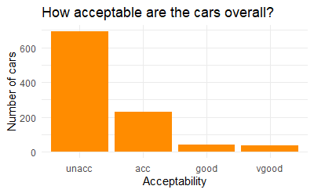

```r
library(ggplot2)

car_records$acceptability <- factor(car_records$acceptability,
                                     levels = c("unacc", "acc", "good", "vgood"))

# Overall spread of acceptability
ggplot(car_records, aes(x = acceptability)) +
  geom_bar(fill = "darkorange") +
  labs(title = "How acceptable are the cars overall?",
       x = "Acceptability", y = "Number of cars") +
  theme_minimal()
```

Most cars are unacc, close to 700 of them. acc is the next biggest group. good and vgood are both small and about the same size. So very few cars are actually rated good — not many cars meet all the good criteria at once.

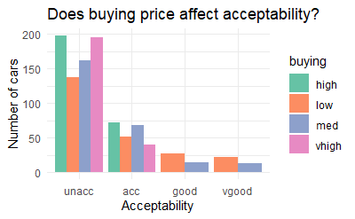

```r
# Acceptability split by buying price
ggplot(car_records, aes(x = acceptability, fill = buying)) +
  geom_bar(position = "dodge") +
  scale_fill_brewer(palette = "Set2") +
  labs(title = "Does buying price affect acceptability?",
       x = "Acceptability", y = "Number of cars") +
  theme_minimal()
```

No high or vhigh buying price cars show up in good or vgood at all — only low and med price cars get those ratings. So a car with an expensive buying price basically can’t be rated good, no matter what else is true about it. Buying price looks like one of the strongest factors here.

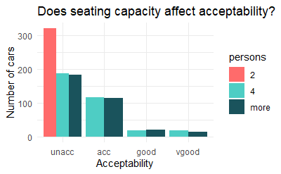

```r
# Extra: acceptability split by number of persons the car seats
ggplot(car_records, aes(x = acceptability, fill = persons)) +
  geom_bar(position = "dodge") +
  scale_fill_manual(values = c("#FF6B6B", "#4ECDC4", "#1A535C")) +
  labs(title = "Does seating capacity affect acceptability?",
       x = "Acceptability", y = "Number of cars") +
  theme_minimal()
```

Cars that seat only 2 people are almost all unacc. None of them get good or vgood. Cars that seat 4 or more can get any rating, including good and vgood. So a 2-seater can’t really be a “good” car in this data, no matter what else about it is nice. This makes sense — a car only 2 people can sit in isn’t very useful for most buyers.

```r
library(infotheo)
feats <- c("buying","maint","doors","persons","lug_boot","safety")
info_scores <- mutinformation(car_records[, feats])
info_scores  # inspect the matrix, ignoring the diagonal
```

```
              buying       maint        doors     persons
buying   1.384665780 0.002630072 0.0026151109 0.001730250
maint    0.002630072 1.385994865 0.0024207885 0.001993803
doors    0.002615111 0.002420789 1.3859951924 0.001125010
persons  0.001730250 0.001993803 0.0011250103 1.098231785
lug_boot 0.001278166 0.000608941 0.0015724629 0.001451442
safety   0.001601456 0.001308771 0.0003522822 0.001774065
             lug_boot       safety
buying   0.0012781665 0.0016014559
maint    0.0006089410 0.0013087713
doors    0.0015724629 0.0003522822
persons  0.0014514422 0.0017740655
lug_boot 1.0983887270 0.0001767061
safety   0.0001767061 1.0985753063
```

## 1.4 Checking how much each feature “tells us” about the others

Regular correlation doesn’t work here because everything is categorical, so I used mutual information instead - it tells us how much knowing one variable reduces our uncertainty about another.

```r
library(infotheo)

info_scores <- mutinformation(car_records)
info_scores
```

```
                   buying       maint        doors     persons
buying        1.384665780 0.002630072 0.0026151109 0.001730250
maint         0.002630072 1.385994865 0.0024207885 0.001993803
doors         0.002615111 0.002420789 1.3859951924 0.001125010
persons       0.001730250 0.001993803 0.0011250103 1.098231785
lug_boot      0.001278166 0.000608941 0.0015724629 0.001451442
safety        0.001601456 0.001308771 0.0003522822 0.001774065
acceptability 0.067509707 0.059097457 0.0039909755 0.149276771
                  lug_boot       safety acceptability
buying        0.0012781665 0.0016014559   0.067509707
maint         0.0006089410 0.0013087713   0.059097457
doors         0.0015724629 0.0003522822   0.003990976
persons       0.0014514422 0.0017740655   0.149276771
lug_boot      1.0983887270 0.0001767061   0.017366220
safety        0.0001767061 1.0985753063   0.191538120
acceptability 0.0173662202 0.1915381199   0.840929362
```

```r
# How informative is each feature about acceptability specifically?
info_scores[-7, 7]
```

```
     buying       maint       doors     persons    lug_boot
0.067509707 0.059097457 0.003990976 0.149276771 0.017366220
     safety
0.191538120
```

Looking at the MI scores against acceptability: safety (0.192) and persons (0.149) stand out as the most informative features. buying (0.068) and maint (0.059) come next, then lug_boot (0.017), and doors (0.004) barely tells us anything. This lines up with what the tables showed earlier and gives a good idea of which features to keep when I do feature selection in part 2a.

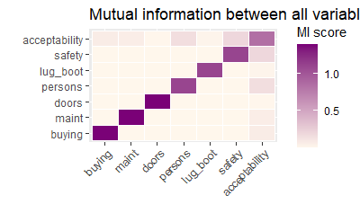

```r
library(reshape2)

info_long <- melt(info_scores)
ggplot(info_long, aes(x = Var1, y = Var2, fill = value)) +
  geom_tile(color = "white") +
  scale_fill_gradient(low = "#FFF7EC", high = "#7A0177") +
  labs(title = "Mutual information between all variables", x = "", y = "", fill = "MI score") +
  theme(axis.text.x = element_text(angle = 45, hjust = 1))
```

The heatmap makes the same pattern easier to see — the acceptability row is darkest under safety and persons, and almost white under doors, confirming those are the weakest and strongest predictors.

## 1.5 Testing independence with chi-squared

```r
chisq.test(car_records$buying, car_records$acceptability)
```

```
    Pearson's Chi-squared test

data:  car_records$buying and car_records$acceptability
X-squared = 113.82, df = 9, p-value < 2.2e-16
```

```r
chisq.test(car_records$buying, car_records$maint)
```

```
    Pearson's Chi-squared test

data:  car_records$buying and car_records$maint
X-squared = 5.3384, df = 9, p-value = 0.8039
```

```r
# Extra check - is boot size independent of acceptability?
chisq.test(car_records$lug_boot, car_records$acceptability)
```

```
    Pearson's Chi-squared test

data:  car_records$lug_boot and car_records$acceptability
X-squared = 24.334, df = 6, p-value = 0.0004533
```

buying and acceptability are linked — the p-value is tiny (less than 2.2e-16), so this isn’t random chance. buying and maint are not linked (p = 0.80), which makes sense since they’re two separate things about a car. lug_boot and acceptability are linked too, but weaker (p = 0.0004533) compared to buying price.

## 1.6 Splitting into training and testing data

This part has to stay exactly as given in the brief so results line up across the class.

```r
library(caTools)
set.seed(123)
split <- sample.split(car_records$acceptability, SplitRatio = 0.8)
train_set <- subset(car_records, split == TRUE)
test_set  <- subset(car_records, split == FALSE)

summary(train_set$acceptability)
```

```
unacc   acc  good vgood
  554   185    33    28
```

```r
summary(test_set$acceptability)
```

```
unacc   acc  good vgood
  139    46     8     7
```

```r
prop.table(table(train_set$acceptability))
```

```
  unacc     acc    good   vgood
0.69250 0.23125 0.04125 0.03500
```

```r
prop.table(table(test_set$acceptability))
```

```
unacc   acc  good vgood
0.695 0.230 0.040 0.035
```

The training and testing sets have almost the same mix of classes. Training is 69.25% unacc, testing is 69.5% unacc — very close. Same for the other classes too. So the split is fair, and it didn’t put too many of one class into just one set.

# Step 2a: Trying out different ML algorithms

### Decision tree (C5.0)

```r
library(caret)
library(C50)

tree_fit  <- C5.0(train_set[-7], train_set$acceptability)
tree_pred <- predict(tree_fit, test_set)
confusionMatrix(tree_pred, test_set$acceptability)
```

```
Confusion Matrix and Statistics

          Reference
Prediction unacc acc good vgood
     unacc   136   1    0     0
     acc       3  43    1     0
     good      0   2    7     0
     vgood     0   0    0     7

Overall Statistics

               Accuracy : 0.965
                 95% CI : (0.9292, 0.9858)
    No Information Rate : 0.695
    P-Value [Acc > NIR] : < 2.2e-16

                  Kappa : 0.925

 Mcnemar's Test P-Value : NA

Statistics by Class:

                     Class: unacc Class: acc Class: good
Sensitivity                0.9784     0.9348      0.8750
Specificity                0.9836     0.9740      0.9896
Pos Pred Value             0.9927     0.9149      0.7778
Neg Pred Value             0.9524     0.9804      0.9948
Prevalence                 0.6950     0.2300      0.0400
Detection Rate             0.6800     0.2150      0.0350
Detection Prevalence       0.6850     0.2350      0.0450
Balanced Accuracy          0.9810     0.9544      0.9323
                     Class: vgood
Sensitivity                 1.000
Specificity                 1.000
Pos Pred Value              1.000
Neg Pred Value              1.000
Prevalence                  0.035
Detection Rate              0.035
Detection Prevalence        0.035
Balanced Accuracy           1.000
```

The decision tree does really well — 96.5% accuracy and a Kappa of 0.925, which is very high (Kappa above 0.8 is usually seen as almost perfect agreement). Looking at each class: vgood is predicted perfectly (100% sensitivity), unacc is also very strong (97.8% sensitivity). good is a bit weaker at 87.5% sensitivity — it’s the smallest class, so the model has less data to learn from it, which explains why it’s slightly less accurate than the others.

```r
library(caret)
library(C50)

cv_ctrl <- trainControl(method = "cv", number = 10)
set.seed(123)

tree_fit_cv  <- train(train_set[, -7], train_set[, 7], method = "C5.0", trControl = cv_ctrl)
tree_pred_cv <- predict(tree_fit_cv, test_set)
confusionMatrix(tree_pred_cv, test_set$acceptability)
```

```
Confusion Matrix and Statistics

          Reference
Prediction unacc acc good vgood
     unacc   139   0    0     0
     acc       0  45    1     0
     good      0   1    7     0
     vgood     0   0    0     7

Overall Statistics

               Accuracy : 0.99
                 95% CI : (0.9643, 0.9988)
    No Information Rate : 0.695
    P-Value [Acc > NIR] : < 2.2e-16

                  Kappa : 0.9783

 Mcnemar's Test P-Value : NA

Statistics by Class:

                     Class: unacc Class: acc Class: good
Sensitivity                 1.000     0.9783      0.8750
Specificity                 1.000     0.9935      0.9948
Pos Pred Value              1.000     0.9783      0.8750
Neg Pred Value              1.000     0.9935      0.9948
Prevalence                  0.695     0.2300      0.0400
Detection Rate              0.695     0.2250      0.0350
Detection Prevalence        0.695     0.2300      0.0400
Balanced Accuracy           1.000     0.9859      0.9349
                     Class: vgood
Sensitivity                 1.000
Specificity                 1.000
Pos Pred Value              1.000
Neg Pred Value              1.000
Prevalence                  0.035
Detection Rate              0.035
Detection Prevalence        0.035
Balanced Accuracy           1.000
```

### Naive Bayes

```r
library(e1071)
set.seed(123)

bayes_fit  <- naiveBayes(train_set[, -7], train_set$acceptability)
bayes_pred <- predict(bayes_fit, test_set)
confusionMatrix(bayes_pred, test_set$acceptability)
```

```
Confusion Matrix and Statistics

          Reference
Prediction unacc acc good vgood
     unacc   130  12    1     0
     acc       9  33    2     4
     good      0   1    5     1
     vgood     0   0    0     2

Overall Statistics

               Accuracy : 0.85
                 95% CI : (0.7928, 0.8965)
    No Information Rate : 0.695
    P-Value [Acc > NIR] : 3.117e-07

                  Kappa : 0.6638

 Mcnemar's Test P-Value : NA

Statistics by Class:

                     Class: unacc Class: acc Class: good
Sensitivity                0.9353     0.7174      0.6250
Specificity                0.7869     0.9026      0.9896
Pos Pred Value             0.9091     0.6875      0.7143
Neg Pred Value             0.8421     0.9145      0.9845
Prevalence                 0.6950     0.2300      0.0400
Detection Rate             0.6500     0.1650      0.0250
Detection Prevalence       0.7150     0.2400      0.0350
Balanced Accuracy          0.8611     0.8100      0.8073
                     Class: vgood
Sensitivity                0.2857
Specificity                1.0000
Pos Pred Value             1.0000
Neg Pred Value             0.9747
Prevalence                 0.0350
Detection Rate             0.0100
Detection Prevalence       0.0100
Balanced Accuracy          0.6429
```

Naive Bayes doesn’t do as well as the decision tree — 85% accuracy and Kappa 0.66, which is decent but not great. The big weak point is vgood — sensitivity is only 0.29, meaning it only catches about 2 out of 7 vgood cars correctly, mixing most of them up with acc. unacc and acc are handled okay, but overall this model is clearly weaker than the decision tree, probably because Naive Bayes assumes features don’t affect each other, which isn’t really true here.

```r
library(caret)
library(C50)

tree_fit  <- C5.0(train_set[-7], train_set$acceptability)
tree_pred <- predict(tree_fit, test_set)
confusionMatrix(tree_pred, test_set$acceptability)
```

```
Confusion Matrix and Statistics

          Reference
Prediction unacc acc good vgood
     unacc   136   1    0     0
     acc       3  43    1     0
     good      0   2    7     0
     vgood     0   0    0     7

Overall Statistics

               Accuracy : 0.965
                 95% CI : (0.9292, 0.9858)
    No Information Rate : 0.695
    P-Value [Acc > NIR] : < 2.2e-16

                  Kappa : 0.925

 Mcnemar's Test P-Value : NA

Statistics by Class:

                     Class: unacc Class: acc Class: good
Sensitivity                0.9784     0.9348      0.8750
Specificity                0.9836     0.9740      0.9896
Pos Pred Value             0.9927     0.9149      0.7778
Neg Pred Value             0.9524     0.9804      0.9948
Prevalence                 0.6950     0.2300      0.0400
Detection Rate             0.6800     0.2150      0.0350
Detection Prevalence       0.6850     0.2350      0.0450
Balanced Accuracy          0.9810     0.9544      0.9323
                     Class: vgood
Sensitivity                 1.000
Specificity                 1.000
Pos Pred Value              1.000
Neg Pred Value              1.000
Prevalence                  0.035
Detection Rate              0.035
Detection Prevalence        0.035
Balanced Accuracy           1.000
```

```r
library(nnet)
set.seed(123)
net_fit  <- nnet(acceptability ~ ., data = train_set, size = 3)
net_pred <- predict(net_fit, test_set, type = "class")
confusionMatrix(factor(net_pred), test_set$acceptability)
```

```
Confusion Matrix and Statistics

          Reference
Prediction unacc acc good vgood
     unacc   135   4    0     0
     acc       4  39    1     0
     good      0   2    7     1
     vgood     0   1    0     6

Overall Statistics

               Accuracy : 0.935
                 95% CI : (0.8914, 0.9649)
    No Information Rate : 0.695
    P-Value [Acc > NIR] : < 2.2e-16

                  Kappa : 0.8597

 Mcnemar's Test P-Value : NA

Statistics by Class:

                     Class: unacc Class: acc Class: good
Sensitivity                0.9712     0.8478      0.8750
Specificity                0.9344     0.9675      0.9844
Pos Pred Value             0.9712     0.8864      0.7000
Neg Pred Value             0.9344     0.9551      0.9947
Prevalence                 0.6950     0.2300      0.0400
Detection Rate             0.6750     0.1950      0.0350
Detection Prevalence       0.6950     0.2200      0.0500
Balanced Accuracy          0.9528     0.9077      0.9297
                     Class: vgood
Sensitivity                0.8571
Specificity                0.9948
Pos Pred Value             0.8571
Neg Pred Value             0.9948
Prevalence                 0.0350
Detection Rate             0.0300
Detection Prevalence       0.0350
Balanced Accuracy          0.9260
```

```r
library(caTools)
set.seed(123)
split <- sample.split(car_records$acceptability, SplitRatio = 0.8)
train_set <- subset(car_records, split == TRUE)
test_set  <- subset(car_records, split == FALSE)

library(kernlab)
svm_fit_a  <- ksvm(acceptability ~ ., data = train_set, kernel = "vanilladot")
svm_pred_a <- predict(svm_fit_a, test_set)
confusionMatrix(svm_pred_a, test_set$acceptability)
```

```
Confusion Matrix and Statistics

          Reference
Prediction unacc acc good vgood
     unacc   133   5    0     0
     acc       6  41    2     0
     good      0   0    6     0
     vgood     0   0    0     7

Overall Statistics

               Accuracy : 0.935
                 95% CI : (0.8914, 0.9649)
    No Information Rate : 0.695
    P-Value [Acc > NIR] : < 2.2e-16

                  Kappa : 0.8592

 Mcnemar's Test P-Value : NA

Statistics by Class:

                     Class: unacc Class: acc Class: good
Sensitivity                0.9568     0.8913      0.7500
Specificity                0.9180     0.9481      1.0000
Pos Pred Value             0.9638     0.8367      1.0000
Neg Pred Value             0.9032     0.9669      0.9897
Prevalence                 0.6950     0.2300      0.0400
Detection Rate             0.6650     0.2050      0.0300
Detection Prevalence       0.6900     0.2450      0.0300
Balanced Accuracy          0.9374     0.9197      0.8750
                     Class: vgood
Sensitivity                 1.000
Specificity                 1.000
Pos Pred Value              1.000
Neg Pred Value              1.000
Prevalence                  0.035
Detection Rate              0.035
Detection Prevalence        0.035
Balanced Accuracy           1.000
```

### Multinomial logistic regression

```r
library(nnet)

logit_fit  <- multinom(acceptability ~ ., data = train_set)
logit_pred <- predict(logit_fit, test_set)
confusionMatrix(logit_pred, test_set$acceptability)
```

```
Confusion Matrix and Statistics

          Reference
Prediction unacc acc good vgood
     unacc   131   1    0     0
     acc       8  44    2     0
     good      0   1    6     1
     vgood     0   0    0     6

Overall Statistics

               Accuracy : 0.935
                 95% CI : (0.8914, 0.9649)
    No Information Rate : 0.695
    P-Value [Acc > NIR] : < 2.2e-16

                  Kappa : 0.8636

 Mcnemar's Test P-Value : NA

Statistics by Class:

                     Class: unacc Class: acc Class: good
Sensitivity                0.9424     0.9565      0.7500
Specificity                0.9836     0.9351      0.9896
Pos Pred Value             0.9924     0.8148      0.7500
Neg Pred Value             0.8824     0.9863      0.9896
Prevalence                 0.6950     0.2300      0.0400
Detection Rate             0.6550     0.2200      0.0300
Detection Prevalence       0.6600     0.2700      0.0400
Balanced Accuracy          0.9630     0.9458      0.8698
                     Class: vgood
Sensitivity                0.8571
Specificity                1.0000
Pos Pred Value             1.0000
Neg Pred Value             0.9948
Prevalence                 0.0350
Detection Rate             0.0300
Detection Prevalence       0.0300
Balanced Accuracy          0.9286
```

Multinomial logistic regression does well too — 93.5% accuracy and Kappa 0.86, which is a big step up from Naive Bayes and close to the decision tree. All four classes are handled fairly evenly this time, with vgood at 0.86 sensitivity and good at 0.75 — no single class is being badly missed like it was with Naive Bayes. So out of the three models so far, the decision tree is still the best, but logistic regression comes in second.

```r
library(nnet)
logit_fit_top3  <- multinom(acceptability ~ persons + lug_boot + safety, data = train_set)
logit_pred_top3 <- predict(logit_fit_top3, test_set)
confusionMatrix(logit_pred_top3, test_set$acceptability)
```

```
Confusion Matrix and Statistics

          Reference
Prediction unacc acc good vgood
     unacc   124   7    0     0
     acc      15  39    8     7
     good      0   0    0     0
     vgood     0   0    0     0

Overall Statistics

               Accuracy : 0.815
                 95% CI : (0.7541, 0.8663)
    No Information Rate : 0.695
    P-Value [Acc > NIR] : 8.287e-05

                  Kappa : 0.6025

 Mcnemar's Test P-Value : NA

Statistics by Class:

                     Class: unacc Class: acc Class: good
Sensitivity                0.8921     0.8478        0.00
Specificity                0.8852     0.8052        1.00
Pos Pred Value             0.9466     0.5652         NaN
Neg Pred Value             0.7826     0.9466        0.96
Prevalence                 0.6950     0.2300        0.04
Detection Rate             0.6200     0.1950        0.00
Detection Prevalence       0.6550     0.3450        0.00
Balanced Accuracy          0.8887     0.8265        0.50
                     Class: vgood
Sensitivity                 0.000
Specificity                 1.000
Pos Pred Value                NaN
Neg Pred Value              0.965
Prevalence                  0.035
Detection Rate              0.000
Detection Prevalence        0.000
Balanced Accuracy           0.500
```

```r
bayes_fit_top3  <- naiveBayes(train_set[, 4:6], train_set$acceptability)
bayes_pred_top3 <- predict(bayes_fit_top3, test_set)
confusionMatrix(bayes_pred_top3, test_set$acceptability)
```

```
Confusion Matrix and Statistics

          Reference
Prediction unacc acc good vgood
     unacc   128  17    3     0
     acc      11  29    5     7
     good      0   0    0     0
     vgood     0   0    0     0

Overall Statistics

               Accuracy : 0.785
                 95% CI : (0.7215, 0.8398)
    No Information Rate : 0.695
    P-Value [Acc > NIR] : 0.00286

                  Kappa : 0.4952

 Mcnemar's Test P-Value : NA

Statistics by Class:

                     Class: unacc Class: acc Class: good
Sensitivity                0.9209     0.6304        0.00
Specificity                0.6721     0.8506        1.00
Pos Pred Value             0.8649     0.5577         NaN
Neg Pred Value             0.7885     0.8851        0.96
Prevalence                 0.6950     0.2300        0.04
Detection Rate             0.6400     0.1450        0.00
Detection Prevalence       0.7400     0.2600        0.00
Balanced Accuracy          0.7965     0.7405        0.50
                     Class: vgood
Sensitivity                 0.000
Specificity                 1.000
Pos Pred Value                NaN
Neg Pred Value              0.965
Prevalence                  0.035
Detection Rate              0.000
Detection Prevalence        0.000
Balanced Accuracy           0.500
```

```r
library(nnet)
set.seed(123)
net_fit  <- nnet(acceptability ~ ., data = train_set, size = 3)
net_pred <- predict(net_fit, test_set, type = "class")
confusionMatrix(factor(net_pred), test_set$acceptability)
```

```
Confusion Matrix and Statistics

          Reference
Prediction unacc acc good vgood
     unacc   135   4    0     0
     acc       4  39    1     0
     good      0   2    7     1
     vgood     0   1    0     6

Overall Statistics

               Accuracy : 0.935
                 95% CI : (0.8914, 0.9649)
    No Information Rate : 0.695
    P-Value [Acc > NIR] : < 2.2e-16

                  Kappa : 0.8597

 Mcnemar's Test P-Value : NA

Statistics by Class:

                     Class: unacc Class: acc Class: good
Sensitivity                0.9712     0.8478      0.8750
Specificity                0.9344     0.9675      0.9844
Pos Pred Value             0.9712     0.8864      0.7000
Neg Pred Value             0.9344     0.9551      0.9947
Prevalence                 0.6950     0.2300      0.0400
Detection Rate             0.6750     0.1950      0.0350
Detection Prevalence       0.6950     0.2200      0.0500
Balanced Accuracy          0.9528     0.9077      0.9297
                     Class: vgood
Sensitivity                0.8571
Specificity                0.9948
Pos Pred Value             0.8571
Neg Pred Value             0.9948
Prevalence                 0.0350
Detection Rate             0.0300
Detection Prevalence       0.0350
Balanced Accuracy          0.9260
```

```r
library(caret)
library(C50)

tree_fit  <- C5.0(train_set[-7], train_set$acceptability)
tree_pred <- predict(tree_fit, test_set)
confusionMatrix(tree_pred, test_set$acceptability)
```

```
Confusion Matrix and Statistics

          Reference
Prediction unacc acc good vgood
     unacc   136   1    0     0
     acc       3  43    1     0
     good      0   2    7     0
     vgood     0   0    0     7

Overall Statistics

               Accuracy : 0.965
                 95% CI : (0.9292, 0.9858)
    No Information Rate : 0.695
    P-Value [Acc > NIR] : < 2.2e-16

                  Kappa : 0.925

 Mcnemar's Test P-Value : NA

Statistics by Class:

                     Class: unacc Class: acc Class: good
Sensitivity                0.9784     0.9348      0.8750
Specificity                0.9836     0.9740      0.9896
Pos Pred Value             0.9927     0.9149      0.7778
Neg Pred Value             0.9524     0.9804      0.9948
Prevalence                 0.6950     0.2300      0.0400
Detection Rate             0.6800     0.2150      0.0350
Detection Prevalence       0.6850     0.2350      0.0450
Balanced Accuracy          0.9810     0.9544      0.9323
                     Class: vgood
Sensitivity                 1.000
Specificity                 1.000
Pos Pred Value              1.000
Neg Pred Value              1.000
Prevalence                  0.035
Detection Rate              0.035
Detection Prevalence        0.035
Balanced Accuracy           1.000
```

```r
library(caret)
library(C50)

tree_fit  <- C5.0(train_set[-7], train_set$acceptability)
tree_pred <- predict(tree_fit, test_set)
confusionMatrix(tree_pred, test_set$acceptability)
```

```
Confusion Matrix and Statistics

          Reference
Prediction unacc acc good vgood
     unacc   136   1    0     0
     acc       3  43    1     0
     good      0   2    7     0
     vgood     0   0    0     7

Overall Statistics

               Accuracy : 0.965
                 95% CI : (0.9292, 0.9858)
    No Information Rate : 0.695
    P-Value [Acc > NIR] : < 2.2e-16

                  Kappa : 0.925

 Mcnemar's Test P-Value : NA

Statistics by Class:

                     Class: unacc Class: acc Class: good
Sensitivity                0.9784     0.9348      0.8750
Specificity                0.9836     0.9740      0.9896
Pos Pred Value             0.9927     0.9149      0.7778
Neg Pred Value             0.9524     0.9804      0.9948
Prevalence                 0.6950     0.2300      0.0400
Detection Rate             0.6800     0.2150      0.0350
Detection Prevalence       0.6850     0.2350      0.0450
Balanced Accuracy          0.9810     0.9544      0.9323
                     Class: vgood
Sensitivity                 1.000
Specificity                 1.000
Pos Pred Value              1.000
Neg Pred Value              1.000
Prevalence                  0.035
Detection Rate              0.035
Detection Prevalence        0.035
Balanced Accuracy           1.000
```

### Support Vector Machine

```r
library(kernlab)

svm_fit_a  <- ksvm(acceptability ~ ., data = train_set, kernel = "vanilladot")
svm_pred_a <- predict(svm_fit_a, test_set)
confusionMatrix(svm_pred_a, test_set$acceptability)
```

```
Confusion Matrix and Statistics

          Reference
Prediction unacc acc good vgood
     unacc   133   5    0     0
     acc       6  41    2     0
     good      0   0    6     0
     vgood     0   0    0     7

Overall Statistics

               Accuracy : 0.935
                 95% CI : (0.8914, 0.9649)
    No Information Rate : 0.695
    P-Value [Acc > NIR] : < 2.2e-16

                  Kappa : 0.8592

 Mcnemar's Test P-Value : NA

Statistics by Class:

                     Class: unacc Class: acc Class: good
Sensitivity                0.9568     0.8913      0.7500
Specificity                0.9180     0.9481      1.0000
Pos Pred Value             0.9638     0.8367      1.0000
Neg Pred Value             0.9032     0.9669      0.9897
Prevalence                 0.6950     0.2300      0.0400
Detection Rate             0.6650     0.2050      0.0300
Detection Prevalence       0.6900     0.2450      0.0300
Balanced Accuracy          0.9374     0.9197      0.8750
                     Class: vgood
Sensitivity                 1.000
Specificity                 1.000
Pos Pred Value              1.000
Neg Pred Value              1.000
Prevalence                  0.035
Detection Rate              0.035
Detection Prevalence        0.035
Balanced Accuracy           1.000
```

SVM with a linear kernel gets 93.5% accuracy and Kappa 0.86 — basically tied with logistic regression. vgood is caught perfectly again (100% sensitivity), and good is at 0.75, same as logistic regression. So right now the decision tree is still ahead of the pack, with logistic regression and SVM close behind each other, and Naive Bayes clearly the weakest so far.

```r
# Trying the e1071 SVM implementation as well, just to compare
svm_fit_b  <- svm(acceptability ~ ., data = train_set)
svm_pred_b <- predict(svm_fit_b, test_set)
confusionMatrix(svm_pred_b, test_set$acceptability)
```

```
Confusion Matrix and Statistics

          Reference
Prediction unacc acc good vgood
     unacc   130   0    0     0
     acc       9  46    8     7
     good      0   0    0     0
     vgood     0   0    0     0

Overall Statistics

               Accuracy : 0.88
                 95% CI : (0.8267, 0.9216)
    No Information Rate : 0.695
    P-Value [Acc > NIR] : 5.983e-10

                  Kappa : 0.7435

 Mcnemar's Test P-Value : NA

Statistics by Class:

                     Class: unacc Class: acc Class: good
Sensitivity                0.9353     1.0000        0.00
Specificity                1.0000     0.8442        1.00
Pos Pred Value             1.0000     0.6571         NaN
Neg Pred Value             0.8714     1.0000        0.96
Prevalence                 0.6950     0.2300        0.04
Detection Rate             0.6500     0.2300        0.00
Detection Prevalence       0.6500     0.3500        0.00
Balanced Accuracy          0.9676     0.9221        0.50
                     Class: vgood
Sensitivity                 0.000
Specificity                 1.000
Pos Pred Value                NaN
Neg Pred Value              0.965
Prevalence                  0.035
Detection Rate              0.000
Detection Prevalence        0.000
Balanced Accuracy           0.500
```

This second SVM (using the e1071 package instead of kernlab) gets 88% accuracy, which looks fine on paper, but Kappa is lower at 0.74. Looking closer, this model completely misses good and vgood — sensitivity is 0.00 for both, meaning it never correctly predicts a single one of them, and just lumps them into acc instead. So even though the accuracy number looks okay, this model is actually worse than the kernlab SVM at the thing that matters — this is exactly why I flagged earlier that accuracy alone can be misleading with imbalanced classes like this.

### Neural network

```r
# Reference: https://www.geeksforgeeks.org/r-language/neural-networks-using-the-r-nnet-package/
net_fit  <- nnet(acceptability ~ ., data = train_set, size = 5)
net_pred <- predict(net_fit, test_set, type = "class")
confusionMatrix(factor(net_pred), test_set$acceptability)
```

```
Confusion Matrix and Statistics

          Reference
Prediction unacc acc good vgood
     unacc   138   4    0     0
     acc       1  40    1     1
     good      0   1    6     0
     vgood     0   1    1     6

Overall Statistics

               Accuracy : 0.95
                 95% CI : (0.91, 0.9758)
    No Information Rate : 0.695
    P-Value [Acc > NIR] : < 2.2e-16

                  Kappa : 0.8899

 Mcnemar's Test P-Value : NA

Statistics by Class:

                     Class: unacc Class: acc Class: good
Sensitivity                0.9928     0.8696      0.7500
Specificity                0.9344     0.9805      0.9948
Pos Pred Value             0.9718     0.9302      0.8571
Neg Pred Value             0.9828     0.9618      0.9896
Prevalence                 0.6950     0.2300      0.0400
Detection Rate             0.6900     0.2000      0.0300
Detection Prevalence       0.7100     0.2150      0.0350
Balanced Accuracy          0.9636     0.9250      0.8724
                     Class: vgood
Sensitivity                0.8571
Specificity                0.9896
Pos Pred Value             0.7500
Neg Pred Value             0.9948
Prevalence                 0.0350
Detection Rate             0.0300
Detection Prevalence       0.0400
Balanced Accuracy          0.9234
```

## Now with cross-validation via caret

### Decision tree with CV

```r
cv_ctrl <- trainControl(method = "cv", number = 10)
set.seed(123)

tree_fit_cv  <- train(train_set[, -7], train_set[, 7], method = "C5.0", trControl = cv_ctrl)
tree_fit_cv
```

```
C5.0

800 samples
  6 predictor
  4 classes: 'unacc', 'acc', 'good', 'vgood'

No pre-processing
Resampling: Cross-Validated (10 fold)
Summary of sample sizes: 720, 720, 720, 719, 719, 721, ...
Resampling results across tuning parameters:

  model  winnow  trials  Accuracy   Kappa
  rules  FALSE    1      0.9399652  0.8707076
  rules  FALSE   10      0.9649193  0.9239429
  rules  FALSE   20      0.9674039  0.9293780
  rules   TRUE    1      0.9374807  0.8657737
  rules   TRUE   10      0.9537619  0.9010344
  rules   TRUE   20      0.9574965  0.9090808
  tree   FALSE    1      0.9399648  0.8709073
  tree   FALSE   10      0.9561844  0.9056297
  tree   FALSE   20      0.9599660  0.9146660
  tree    TRUE    1      0.9387148  0.8685632
  tree    TRUE   10      0.9437615  0.8799486
  tree    TRUE   20      0.9475586  0.8884975

Accuracy was used to select the optimal model using the
 largest value.
The final values used for the model were trials = 20, model
 = rules and winnow = FALSE.
```

```r
tree_pred_cv <- predict(tree_fit_cv, test_set)
confusionMatrix(tree_pred_cv, test_set$acceptability)
```

```
Confusion Matrix and Statistics

          Reference
Prediction unacc acc good vgood
     unacc   139   0    0     0
     acc       0  45    1     0
     good      0   1    7     0
     vgood     0   0    0     7

Overall Statistics

               Accuracy : 0.99
                 95% CI : (0.9643, 0.9988)
    No Information Rate : 0.695
    P-Value [Acc > NIR] : < 2.2e-16

                  Kappa : 0.9783

 Mcnemar's Test P-Value : NA

Statistics by Class:

                     Class: unacc Class: acc Class: good
Sensitivity                 1.000     0.9783      0.8750
Specificity                 1.000     0.9935      0.9948
Pos Pred Value              1.000     0.9783      0.8750
Neg Pred Value              1.000     0.9935      0.9948
Prevalence                  0.695     0.2300      0.0400
Detection Rate              0.695     0.2250      0.0350
Detection Prevalence        0.695     0.2300      0.0400
Balanced Accuracy           1.000     0.9859      0.9349
                     Class: vgood
Sensitivity                 1.000
Specificity                 1.000
Pos Pred Value              1.000
Neg Pred Value              1.000
Prevalence                  0.035
Detection Rate              0.035
Detection Prevalence        0.035
Balanced Accuracy           1.000
```

Cross-validation pushed the decision tree up to 99% accuracy and Kappa 0.978, better than the basic version (96.5%). Caret tried different combos of trials, model, and winnow, and picked trials = 20, model = rules, winnow = FALSE as the best. Every class does well now, even good, which was the weak spot before. Shows tuning actually helps.

```r
library(caret)
library(C50)

cv_ctrl <- trainControl(method = "cv", number = 10)
set.seed(123)

tree_fit_cv  <- train(train_set[, -7], train_set[, 7], method = "C5.0", trControl = cv_ctrl)
tree_pred_cv <- predict(tree_fit_cv, test_set)
confusionMatrix(tree_pred_cv, test_set$acceptability)
```

```
Confusion Matrix and Statistics

          Reference
Prediction unacc acc good vgood
     unacc   139   0    0     0
     acc       0  45    1     0
     good      0   1    7     0
     vgood     0   0    0     7

Overall Statistics

               Accuracy : 0.99
                 95% CI : (0.9643, 0.9988)
    No Information Rate : 0.695
    P-Value [Acc > NIR] : < 2.2e-16

                  Kappa : 0.9783

 Mcnemar's Test P-Value : NA

Statistics by Class:

                     Class: unacc Class: acc Class: good
Sensitivity                 1.000     0.9783      0.8750
Specificity                 1.000     0.9935      0.9948
Pos Pred Value              1.000     0.9783      0.8750
Neg Pred Value              1.000     0.9935      0.9948
Prevalence                  0.695     0.2300      0.0400
Detection Rate              0.695     0.2250      0.0350
Detection Prevalence        0.695     0.2300      0.0400
Balanced Accuracy           1.000     0.9859      0.9349
                     Class: vgood
Sensitivity                 1.000
Specificity                 1.000
Pos Pred Value              1.000
Neg Pred Value              1.000
Prevalence                  0.035
Detection Rate              0.035
Detection Prevalence        0.035
Balanced Accuracy           1.000
```

```r
logit_fit_top3  <- multinom(acceptability ~ persons + lug_boot + safety, data = train_set)
logit_pred_top3 <- predict(logit_fit_top3, test_set)
confusionMatrix(logit_pred_top3, test_set$acceptability)
```

```
Confusion Matrix and Statistics

          Reference
Prediction unacc acc good vgood
     unacc   124   7    0     0
     acc      15  39    8     7
     good      0   0    0     0
     vgood     0   0    0     0

Overall Statistics

               Accuracy : 0.815
                 95% CI : (0.7541, 0.8663)
    No Information Rate : 0.695
    P-Value [Acc > NIR] : 8.287e-05

                  Kappa : 0.6025

 Mcnemar's Test P-Value : NA

Statistics by Class:

                     Class: unacc Class: acc Class: good
Sensitivity                0.8921     0.8478        0.00
Specificity                0.8852     0.8052        1.00
Pos Pred Value             0.9466     0.5652         NaN
Neg Pred Value             0.7826     0.9466        0.96
Prevalence                 0.6950     0.2300        0.04
Detection Rate             0.6200     0.1950        0.00
Detection Prevalence       0.6550     0.3450        0.00
Balanced Accuracy          0.8887     0.8265        0.50
                     Class: vgood
Sensitivity                 0.000
Specificity                 1.000
Pos Pred Value                NaN
Neg Pred Value              0.965
Prevalence                  0.035
Detection Rate              0.000
Detection Prevalence        0.000
Balanced Accuracy           0.500
```

### Naive Bayes with CV

```r
cv_ctrl <- trainControl(method = "cv", number = 10)
set.seed(123)

bayes_fit_cv  <- train(train_set[, -7], train_set[, 7], method = "nb", trControl = cv_ctrl)
bayes_fit_cv
```

```
Naive Bayes

800 samples
  6 predictor
  4 classes: 'unacc', 'acc', 'good', 'vgood'

No pre-processing
Resampling: Cross-Validated (10 fold)
Summary of sample sizes: 720, 720, 720, 719, 719, 721, ...
Resampling results across tuning parameters:

  usekernel  Accuracy   Kappa
  FALSE      0.8362418  0.6274638
   TRUE      0.8362418  0.6274638

Tuning parameter 'fL' was held constant at a value of 0

Tuning parameter 'adjust' was held constant at a value of 1
Accuracy was used to select the optimal model using the
 largest value.
The final values used for the model were fL = 0, usekernel
 = FALSE and adjust = 1.
```

```r
bayes_pred_cv <- predict(bayes_fit_cv, test_set)
confusionMatrix(bayes_pred_cv, test_set$acceptability)
```

```
Confusion Matrix and Statistics

          Reference
Prediction unacc acc good vgood
     unacc   130  12    1     0
     acc       9  33    2     4
     good      0   1    5     1
     vgood     0   0    0     2

Overall Statistics

               Accuracy : 0.85
                 95% CI : (0.7928, 0.8965)
    No Information Rate : 0.695
    P-Value [Acc > NIR] : 3.117e-07

                  Kappa : 0.6638

 Mcnemar's Test P-Value : NA

Statistics by Class:

                     Class: unacc Class: acc Class: good
Sensitivity                0.9353     0.7174      0.6250
Specificity                0.7869     0.9026      0.9896
Pos Pred Value             0.9091     0.6875      0.7143
Neg Pred Value             0.8421     0.9145      0.9845
Prevalence                 0.6950     0.2300      0.0400
Detection Rate             0.6500     0.1650      0.0250
Detection Prevalence       0.7150     0.2400      0.0350
Balanced Accuracy          0.8611     0.8100      0.8073
                     Class: vgood
Sensitivity                0.2857
Specificity                1.0000
Pos Pred Value             1.0000
Neg Pred Value             0.9747
Prevalence                 0.0350
Detection Rate             0.0100
Detection Prevalence       0.0100
Balanced Accuracy          0.6429
```

This CV version of Naive Bayes gets the exact same result as the basic one — 85% accuracy, Kappa 0.66. That’s because fL was held fixed at 0 and only usekernel was tried (FALSE vs TRUE), and both gave the same score anyway. So cross-validation didn’t actually improve anything here, since the real tuning of fL happens later in part 2b. vgood is still the weak spot, same as before — sensitivity only 0.29.

### Logistic regression with CV

```r
cv_ctrl <- trainControl(method = "cv", number = 10)
set.seed(123)

logit_fit_cv  <- train(train_set[, -7], train_set[, 7], method = "multinom",
                        trControl = cv_ctrl, trace = FALSE)
logit_fit_cv
```

```
Penalized Multinomial Regression

800 samples
  6 predictor
  4 classes: 'unacc', 'acc', 'good', 'vgood'

No pre-processing
Resampling: Cross-Validated (10 fold)
Summary of sample sizes: 720, 720, 720, 719, 719, 721, ...
Resampling results across tuning parameters:

  decay  Accuracy   Kappa
  0e+00  0.9249795  0.8394418
  1e-04  0.9249945  0.8396601
  1e-01  0.8813684  0.7413285

Accuracy was used to select the optimal model using the
 largest value.
The final value used for the model was decay = 1e-04.
```

```r
logit_pred_cv <- predict(logit_fit_cv, test_set)
confusionMatrix(logit_pred_cv, test_set$acceptability)
```

```
Confusion Matrix and Statistics

          Reference
Prediction unacc acc good vgood
     unacc   131   1    0     0
     acc       8  43    2     0
     good      0   1    6     1
     vgood     0   1    0     6

Overall Statistics

               Accuracy : 0.93
                 95% CI : (0.8853, 0.9612)
    No Information Rate : 0.695
    P-Value [Acc > NIR] : 3.476e-16

                  Kappa : 0.8534

 Mcnemar's Test P-Value : NA

Statistics by Class:

                     Class: unacc Class: acc Class: good
Sensitivity                0.9424     0.9348      0.7500
Specificity                0.9836     0.9351      0.9896
Pos Pred Value             0.9924     0.8113      0.7500
Neg Pred Value             0.8824     0.9796      0.9896
Prevalence                 0.6950     0.2300      0.0400
Detection Rate             0.6550     0.2150      0.0300
Detection Prevalence       0.6600     0.2650      0.0400
Balanced Accuracy          0.9630     0.9349      0.8698
                     Class: vgood
Sensitivity                0.8571
Specificity                0.9948
Pos Pred Value             0.8571
Neg Pred Value             0.9948
Prevalence                 0.0350
Detection Rate             0.0300
Detection Prevalence       0.0350
Balanced Accuracy          0.9260
```

The CV version of logistic regression gets 93% accuracy and Kappa 0.85, basically the same as the basic version (93.5%, Kappa 0.86) — no real improvement here. Caret tried three decay values (0, 1e-04, 1e-01) and picked decay = 1e-04 as best, though the difference between 0 and 1e-04 is tiny. This makes sense since logistic regression doesn’t have much to tune compared to something like a decision tree.

### Neural network with CV

```r
cv_ctrl <- trainControl(method = "cv", number = 10)
set.seed(123)

net_fit_cv  <- train(train_set[, -7], train_set[, 7], method = "nnet",
                      trControl = cv_ctrl, trace = FALSE)
net_fit_cv
```

```
Neural Network

800 samples
  6 predictor
  4 classes: 'unacc', 'acc', 'good', 'vgood'

No pre-processing
Resampling: Cross-Validated (10 fold)
Summary of sample sizes: 720, 720, 720, 719, 719, 721, ...
Resampling results across tuning parameters:

  size  decay  Accuracy   Kappa
  1     0e+00  0.9149008  0.8171319
  1     1e-04  0.9112920  0.8099249
  1     1e-01  0.8825084  0.7379648
  3     0e+00  0.9376053  0.8674752
  3     1e-04  0.9275416  0.8424557
  3     1e-01  0.9449340  0.8820046
  5     0e+00  0.9475582  0.8892958
  5     1e-04  0.9463399  0.8868588
  5     1e-01  0.9550594  0.9042634

Accuracy was used to select the optimal model using the
 largest value.
The final values used for the model were size = 5 and decay
 = 0.1.
```

```r
net_pred_cv <- predict(net_fit_cv, test_set)
confusionMatrix(net_pred_cv, test_set$acceptability)
```

```
Confusion Matrix and Statistics

          Reference
Prediction unacc acc good vgood
     unacc   139   1    0     0
     acc       0  44    1     0
     good      0   0    7     1
     vgood     0   1    0     6

Overall Statistics

               Accuracy : 0.98
                 95% CI : (0.9496, 0.9945)
    No Information Rate : 0.695
    P-Value [Acc > NIR] : < 2.2e-16

                  Kappa : 0.9564

 Mcnemar's Test P-Value : NA

Statistics by Class:

                     Class: unacc Class: acc Class: good
Sensitivity                1.0000     0.9565      0.8750
Specificity                0.9836     0.9935      0.9948
Pos Pred Value             0.9929     0.9778      0.8750
Neg Pred Value             1.0000     0.9871      0.9948
Prevalence                 0.6950     0.2300      0.0400
Detection Rate             0.6950     0.2200      0.0350
Detection Prevalence       0.7000     0.2250      0.0400
Balanced Accuracy          0.9918     0.9750      0.9349
                     Class: vgood
Sensitivity                0.8571
Specificity                0.9948
Pos Pred Value             0.8571
Neg Pred Value             0.9948
Prevalence                 0.0350
Detection Rate             0.0300
Detection Prevalence       0.0350
Balanced Accuracy          0.9260
```

### SVM with CV

```r
set.seed(123)
svm_fit_cv  <- ksvm(acceptability ~ ., data = train_set, kernel = "vanilladot", cross = 10)
svm_fit_cv
```

```
Support Vector Machine object of class "ksvm"

SV type: C-svc  (classification)
 parameter : cost C = 1

Linear (vanilla) kernel function.

Number of Support Vectors : 293

Objective Function Value : -137.875 -20 -11.7143 -40.9483 -17.3171 -14
Training error : 0.0725
Cross validation error : 0.0975
```

```r
svm_pred_cv <- predict(svm_fit_cv, test_set)
confusionMatrix(svm_pred_cv, test_set$acceptability)
```

```
Confusion Matrix and Statistics

          Reference
Prediction unacc acc good vgood
     unacc   133   5    0     0
     acc       6  41    2     0
     good      0   0    6     0
     vgood     0   0    0     7

Overall Statistics

               Accuracy : 0.935
                 95% CI : (0.8914, 0.9649)
    No Information Rate : 0.695
    P-Value [Acc > NIR] : < 2.2e-16

                  Kappa : 0.8592

 Mcnemar's Test P-Value : NA

Statistics by Class:

                     Class: unacc Class: acc Class: good
Sensitivity                0.9568     0.8913      0.7500
Specificity                0.9180     0.9481      1.0000
Pos Pred Value             0.9638     0.8367      1.0000
Neg Pred Value             0.9032     0.9669      0.9897
Prevalence                 0.6950     0.2300      0.0400
Detection Rate             0.6650     0.2050      0.0300
Detection Prevalence       0.6900     0.2450      0.0300
Balanced Accuracy          0.9374     0.9197      0.8750
                     Class: vgood
Sensitivity                 1.000
Specificity                 1.000
Pos Pred Value              1.000
Neg Pred Value              1.000
Prevalence                  0.035
Detection Rate              0.035
Detection Prevalence        0.035
Balanced Accuracy           1.000
```

This SVM used ksvm’s own built-in cross = 10 option instead of caret, but the numbers came out exactly the same as the basic SVM from before — 93.5% accuracy, Kappa 0.86. The cross-validation error shown (0.0975) is a bit higher than the training error (0.0725), which is normal and just means the model does slightly worse on unseen folds than on the data it trained on. Since the linear kernel has no real hyperparameters to tune here, it’s expected that CV doesn’t change the result much.

## Picking the best features using mutual information

```r
info_train <- mutinformation(train_set)
info_train
```

```
                   buying       maint        doors     persons
buying        1.385315887 0.004934093 0.0031569811 0.002123370
maint         0.004934093 1.385913061 0.0040869702 0.001664435
doors         0.003156981 0.004086970 1.3855850753 0.001706556
persons       0.002123370 0.001664435 0.0017065558 1.097043828
lug_boot      0.000601026 0.002225754 0.0012412893 0.001142421
safety        0.002836805 0.002754139 0.0004533454 0.002709021
acceptability 0.068884377 0.056801147 0.0047545261 0.142776703
                  lug_boot       safety acceptability
buying        0.0006010260 0.0028368049   0.068884377
maint         0.0022257538 0.0027541390   0.056801147
doors         0.0012412893 0.0004533454   0.004754526
persons       0.0011424209 0.0027090205   0.142776703
lug_boot      1.0983757541 0.0005431372   0.018915597
safety        0.0005431372 1.0984936775   0.190838246
acceptability 0.0189155965 0.1908382461   0.841909803
```

```r
info_train[7, -7]
```

```
     buying       maint       doors     persons    lug_boot
0.068884377 0.056801147 0.004754526 0.142776703 0.018915597
     safety
0.190838246
```

On the training data, safety (0.191) and persons (0.143) come out as the strongest again, same as before on the full dataset — so the pattern holds even after splitting.

```r
# Trying a range of x values to see how accuracy changes
for (x in 2:5) {
  top_features <- names(sort(info_train[7, -7], decreasing = TRUE))[1:x]
  tree_fit_x  <- C5.0(train_set[, top_features], train_set$acceptability)
  tree_pred_x <- predict(tree_fit_x, test_set)
  acc_x <- confusionMatrix(tree_pred_x, test_set$acceptability)$overall["Accuracy"]
  cat("x =", x, "-> Accuracy:", round(acc_x, 4), "\n")
}
```

```
x = 2 -> Accuracy: 0.8
x = 3 -> Accuracy: 0.82
x = 4 -> Accuracy: 0.885
x = 5 -> Accuracy: 0.93
```

Accuracy keeps going up as more features are added — x = 2 gives 80%, x = 3 gives 82%, x = 4 jumps to 88.5%, and x = 5 gets to 93%. So dropping too many features really hurts the model. Even though safety and persons had the highest MI scores alone, the other features still add useful information. This shows there’s no shortcut — using more features (closer to all 6) gives better results than picking just the top few.

### Decision tree with fewer features

```r
tree_fit_top3  <- C5.0(train_set[, 4:6], train_set$acceptability)
tree_pred_top3 <- predict(tree_fit_top3, test_set)
confusionMatrix(tree_pred_top3, test_set$acceptability)
```

```
Confusion Matrix and Statistics

          Reference
Prediction unacc acc good vgood
     unacc   124   7    0     0
     acc      15  39    8     7
     good      0   0    0     0
     vgood     0   0    0     0

Overall Statistics

               Accuracy : 0.815
                 95% CI : (0.7541, 0.8663)
    No Information Rate : 0.695
    P-Value [Acc > NIR] : 8.287e-05

                  Kappa : 0.6025

 Mcnemar's Test P-Value : NA

Statistics by Class:

                     Class: unacc Class: acc Class: good
Sensitivity                0.8921     0.8478        0.00
Specificity                0.8852     0.8052        1.00
Pos Pred Value             0.9466     0.5652         NaN
Neg Pred Value             0.7826     0.9466        0.96
Prevalence                 0.6950     0.2300        0.04
Detection Rate             0.6200     0.1950        0.00
Detection Prevalence       0.6550     0.3450        0.00
Balanced Accuracy          0.8887     0.8265        0.50
                     Class: vgood
Sensitivity                 0.000
Specificity                 1.000
Pos Pred Value                NaN
Neg Pred Value              0.965
Prevalence                  0.035
Detection Rate              0.000
Detection Prevalence        0.000
Balanced Accuracy           0.500
```

### Naive Bayes with fewer features

```r
bayes_fit_top3  <- naiveBayes(train_set[, 4:6], train_set$acceptability)
bayes_pred_top3 <- predict(bayes_fit_top3, test_set)
confusionMatrix(bayes_pred_top3, test_set$acceptability)
```

```
Confusion Matrix and Statistics

          Reference
Prediction unacc acc good vgood
     unacc   128  17    3     0
     acc      11  29    5     7
     good      0   0    0     0
     vgood     0   0    0     0

Overall Statistics

               Accuracy : 0.785
                 95% CI : (0.7215, 0.8398)
    No Information Rate : 0.695
    P-Value [Acc > NIR] : 0.00286

                  Kappa : 0.4952

 Mcnemar's Test P-Value : NA

Statistics by Class:

                     Class: unacc Class: acc Class: good
Sensitivity                0.9209     0.6304        0.00
Specificity                0.6721     0.8506        1.00
Pos Pred Value             0.8649     0.5577         NaN
Neg Pred Value             0.7885     0.8851        0.96
Prevalence                 0.6950     0.2300        0.04
Detection Rate             0.6400     0.1450        0.00
Detection Prevalence       0.7400     0.2600        0.00
Balanced Accuracy          0.7965     0.7405        0.50
                     Class: vgood
Sensitivity                 0.000
Specificity                 1.000
Pos Pred Value                NaN
Neg Pred Value              0.965
Prevalence                  0.035
Detection Rate              0.000
Detection Prevalence        0.000
Balanced Accuracy           0.500
```

### Logistic regression with fewer features

```r
logit_fit_top3  <- multinom(acceptability ~ persons + lug_boot + safety, data = train_set)
logit_pred_top3 <- predict(logit_fit_top3, test_set)
confusionMatrix(logit_pred_top3, test_set$acceptability)
```

```
Confusion Matrix and Statistics

          Reference
Prediction unacc acc good vgood
     unacc   124   7    0     0
     acc      15  39    8     7
     good      0   0    0     0
     vgood     0   0    0     0

Overall Statistics

               Accuracy : 0.815
                 95% CI : (0.7541, 0.8663)
    No Information Rate : 0.695
    P-Value [Acc > NIR] : 8.287e-05

                  Kappa : 0.6025

 Mcnemar's Test P-Value : NA

Statistics by Class:

                     Class: unacc Class: acc Class: good
Sensitivity                0.8921     0.8478        0.00
Specificity                0.8852     0.8052        1.00
Pos Pred Value             0.9466     0.5652         NaN
Neg Pred Value             0.7826     0.9466        0.96
Prevalence                 0.6950     0.2300        0.04
Detection Rate             0.6200     0.1950        0.00
Detection Prevalence       0.6550     0.3450        0.00
Balanced Accuracy          0.8887     0.8265        0.50
                     Class: vgood
Sensitivity                 0.000
Specificity                 1.000
Pos Pred Value                NaN
Neg Pred Value              0.965
Prevalence                  0.035
Detection Rate              0.000
Detection Prevalence        0.000
Balanced Accuracy           0.500
```

### SVM with fewer features

```r
svm_fit_top3  <- ksvm(acceptability ~ persons + lug_boot + safety, data = train_set, kernel = "vanilladot")
svm_pred_top3 <- predict(svm_fit_top3, test_set)
confusionMatrix(svm_pred_top3, test_set$acceptability)
```

```
Confusion Matrix and Statistics

          Reference
Prediction unacc acc good vgood
     unacc   128  16    2     0
     acc      11  30    6     7
     good      0   0    0     0
     vgood     0   0    0     0

Overall Statistics

               Accuracy : 0.79
                 95% CI : (0.7269, 0.8443)
    No Information Rate : 0.695
    P-Value [Acc > NIR] : 0.001704

                  Kappa : 0.5123

 Mcnemar's Test P-Value : NA

Statistics by Class:

                     Class: unacc Class: acc Class: good
Sensitivity                0.9209     0.6522        0.00
Specificity                0.7049     0.8442        1.00
Pos Pred Value             0.8767     0.5556         NaN
Neg Pred Value             0.7963     0.8904        0.96
Prevalence                 0.6950     0.2300        0.04
Detection Rate             0.6400     0.1500        0.00
Detection Prevalence       0.7300     0.2700        0.00
Balanced Accuracy          0.8129     0.7482        0.50
                     Class: vgood
Sensitivity                 0.000
Specificity                 1.000
Pos Pred Value                NaN
Neg Pred Value              0.965
Prevalence                  0.035
Detection Rate              0.000
Detection Prevalence        0.000
Balanced Accuracy           0.500
```

```r
bayes_fit_top3  <- naiveBayes(train_set[, 4:6], train_set$acceptability)
bayes_pred_top3 <- predict(bayes_fit_top3, test_set)
confusionMatrix(bayes_pred_top3, test_set$acceptability)
```

```
Confusion Matrix and Statistics

          Reference
Prediction unacc acc good vgood
     unacc   128  17    3     0
     acc      11  29    5     7
     good      0   0    0     0
     vgood     0   0    0     0

Overall Statistics

               Accuracy : 0.785
                 95% CI : (0.7215, 0.8398)
    No Information Rate : 0.695
    P-Value [Acc > NIR] : 0.00286

                  Kappa : 0.4952

 Mcnemar's Test P-Value : NA

Statistics by Class:

                     Class: unacc Class: acc Class: good
Sensitivity                0.9209     0.6304        0.00
Specificity                0.6721     0.8506        1.00
Pos Pred Value             0.8649     0.5577         NaN
Neg Pred Value             0.7885     0.8851        0.96
Prevalence                 0.6950     0.2300        0.04
Detection Rate             0.6400     0.1450        0.00
Detection Prevalence       0.7400     0.2600        0.00
Balanced Accuracy          0.7965     0.7405        0.50
                     Class: vgood
Sensitivity                 0.000
Specificity                 1.000
Pos Pred Value                NaN
Neg Pred Value              0.965
Prevalence                  0.035
Detection Rate              0.000
Detection Prevalence        0.000
Balanced Accuracy           0.500
```